### My Project On Activity Monitor Data

It is now possible to collect a large amount of data about personal movement using activity monitoring devices such as a Fitbit, Nike Fuelband, or Jawbone Up. These type of devices are part of the “quantified self” movement – a group of enthusiasts who take measurements about themselves regularly to improve their health, to find patterns in their behavior, or because they are tech geeks. Now we will investigate the these activity data to find if there are any interesting patterns hidden in it. **First investigation:What is mean total number of steps taken per day?

```r
#initiate related packages
library(dplyr)
```

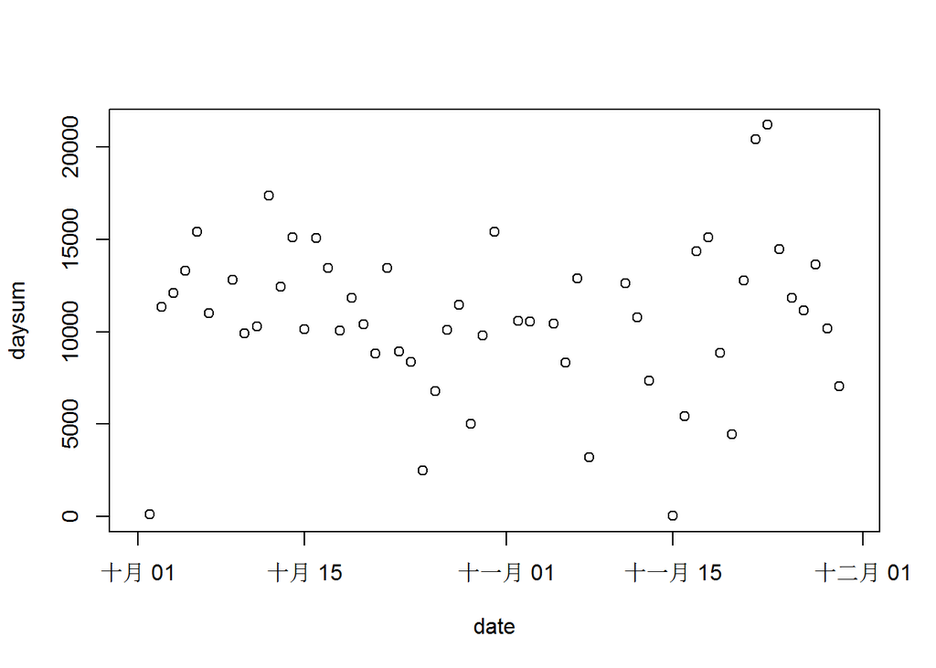

```r
library(tidyr)
library(ggplot2)
#load data into R
mydata<-read.csv(file="C:/Users/siteng/Documents/data/activity.csv")
#set date varible in the date format
mydata$date<-as.Date(as.character(mydata$date),"%Y-%m-%d")
##What is mean total number of steps taken per day?
mydata2<-mydata%>%group_by(date)%>%summarise(daysum=sum(steps))
with(mydata2,plot(date,daysum))
```

```r
summary(mydata2$daysum)
```

```
##    Min. 1st Qu.  Median    Mean 3rd Qu.    Max.    NA's
##      41    8841   10760   10770   13290   21190       8
```

From the plot it is easy to see the mean total number of steps taken per day is up and down from about 0 to 20000 steps. The mean of mean and median total number of steps taken per day is 10770 and 10760. #The second investigation:What is the average daily activity pattern?

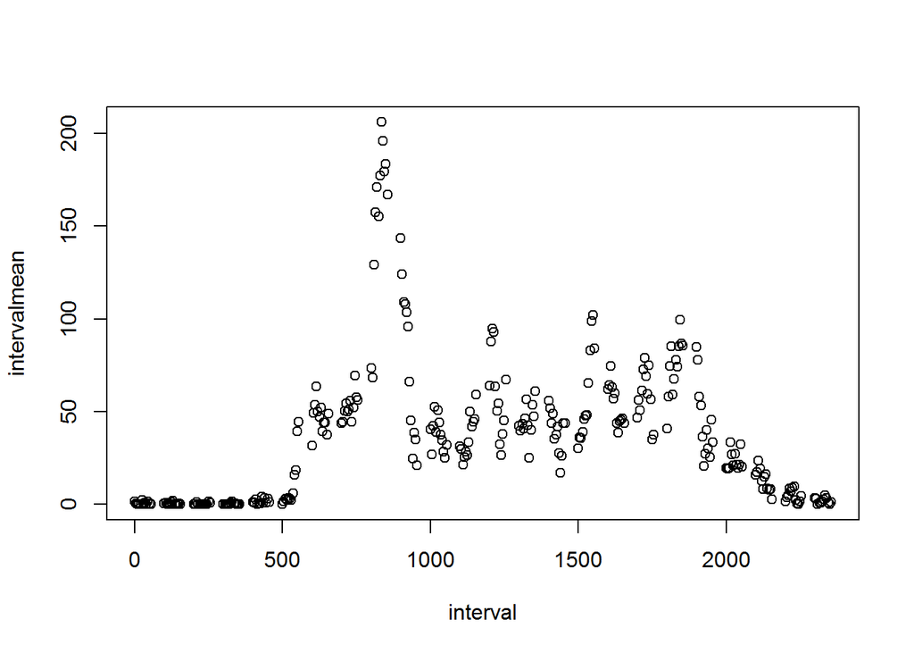

```r
mydata3<-mydata%>%group_by(interval)%>%summarise(intervalmean=mean(steps,na.rm=TRUE))
with(mydata3,plot(interval,intervalmean))
```

```r
which.max(mydata3$intervalmean)
```

```
## [1] 104
```

```r
mydata3$interval[104]
```

```
## [1] 835
```

```r
sum(is.na(mydata$steps))
```

```
## [1] 2304
```

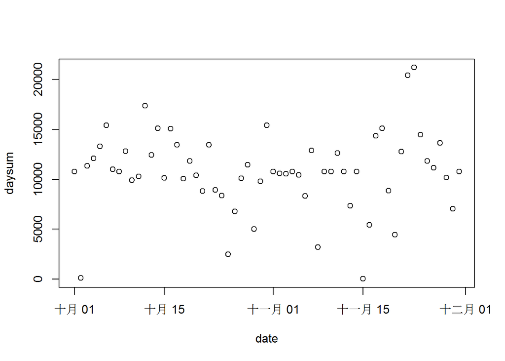

```r
mydata4<-mydata
for(i in 1:length(mydata4$steps)){
        if(is.na(mydata4$steps[i]))
                mydata4$revisedsteps[i]<-as.numeric(filter(mydata3,interval==mydata4$interval[i])[2])
        else
                mydata4$revisedsteps[i]<-mydata4$steps[i]
}
mydata5<-mydata4%>%group_by(date)%>%summarise(daysum=sum(revisedsteps))
with(mydata5,plot(date,daysum))
```

```r
summary(mydata5$daysum)
```

```
##    Min. 1st Qu.  Median    Mean 3rd Qu.    Max.
##      41    9819   10770   10770   12810   21190
```

We can see the mean and median total number of steps taken per day are similar of the estimates from the first part of the assignment. **Are there differences in activity patterns between weekdays and weekends?

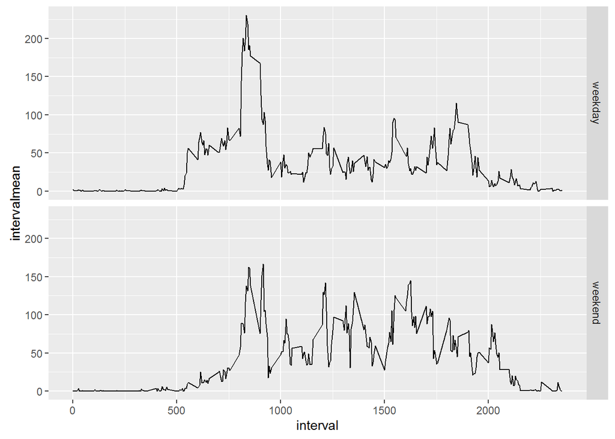

```r
mydata6<-mutate(mydata4,weekday=character(17568))
for(i in 1:length(mydata6$steps)){
        if(weekdays(mydata6$date[i])%in%c("星期六","星期日"))
        mydata6$weekday[i]<-"weekend"
else
        mydata6$weekday[i]<-"weekday"
}
mydata6$weekday<-as.factor(mydata6$weekday)
mydata7<-mydata6%>%group_by(weekday,interval)%>%summarise(intervalmean=mean(revisedsteps))
g<-ggplot(data=mydata7,aes(interval,intervalmean))
g+geom_line()+facet_grid(weekday~.)
```

From the plot above we can see there is a slightly different shift over weekdays and weekends activity. It is a resonable guess the shift is due to the get up time difference between weekdays and weekends.